# R Notebook

[output not shown]

#——————————————————-# # Ejemplo distritos # #——————————————————-#

```
re-encoding from CP1252
```

`r`r colnames(distritos) <- tolower(colnames(distritos)) nombres=distritos[,1] distritos=distritos[,-1] rownames(distritos)=nombres head(distritos)

|  | ocu_vivi | pobpjov | sinelect | sinagua | pea1619 | pocprin | peam15 |
| --- | --- | --- | --- | --- | --- | --- | --- |
| Ate | 1.15 | 5.3 | 27.60 | 51.10 | 3.9 | 1.1 | 63.48 |
| Barranco | 1.09 | 4.5 | 1.59 | 8.32 | 0.8 | 3.9 | 33.48 |
| Breña | 1.08 | 4.4 | 2.20 | 23.15 | 0.9 | 4.0 | 37.89 |
| Carabayllo | 1.10 | 5.1 | 30.13 | 38.09 | 4.5 | 12.6 | 63.65 |
| Comas | 1.20 | 5.9 | 10.92 | 24.27 | 3.8 | 9.4 | 60.37 |
| Chorrillos | 1.15 | 5.5 | 16.77 | 37.11 | 3.2 | 10.6 | 18.78 |

# CLARA

CLARA : Tecnica particional, por lo tanto se debe indicar la cantida de K media

`r`r library() res=clara(scale(distritos),2) res

```
Call:    clara(x = scale(distritos), k = 2)
Medoids:
                                 ocu_vivi    pobpjov   sinelect
San Juan de Miraflores          0.5141271  0.5714769  1.0211988
Magdalena del Mar              -0.5317041 -0.7947101 -0.8085748
                                  sinagua    pea1619    pocprin
San Juan de Miraflores          1.1196499  1.2455772  1.0645749
Magdalena del Mar              -0.6737858 -0.8939102 -0.8848637
                                   peam15
San Juan de Miraflores          0.9067534
Magdalena del Mar              -0.8586552
Objective function:  1.598154
Clustering vector:   Named int [1:34] 1 2 2 1 1 1 1 1 2 2 2 2 1 1 2 2 2 2 ...
 - attr(*, \names\)= chr [1:34] \Ate                           \ \Barranco                      \ \Breña                         \ \Carabayllo                    \ \Comas                         \ \Chorrillos                    \ \Agustino                      \ ...
Cluster sizes:           15 19
Best sample:
 [1] Ate                            Barranco
 [3] Breña                          Carabayllo
 [5] Comas                          Chorrillos
 [7] Agustino                       Independencia
 [9] Jesús María                    La Victoria
[11] Lima                           Lince
[13] Los Olivos                     Lurigancho-Chosica
[15] Magdalena del Mar              Pueblo Libre
[17] Miraflores                     Rímac
[19] San Borja                      San Isidro
[21] San Juan de Lurigancho         San Juan de Miraflores
[23] San Luis                       San Martin de Porres
[25] San Miguel                     Santa Anita
[27] Surco                          Surquillo
[29] Villa el Salvador              Villa María del Triunfo
[31] Callao                         Carmen de la Legua
[33] La Perla                       La Punta

Available components:
 [1] \sample\     \medoids\    \i.med\      \clustering\ \objective\
 [6] \clusinfo\   \diss\       \call\       \silinfo\    \data\
```

`r`r plot(res)

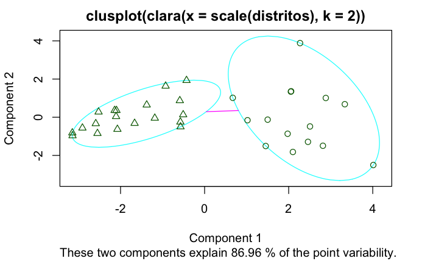

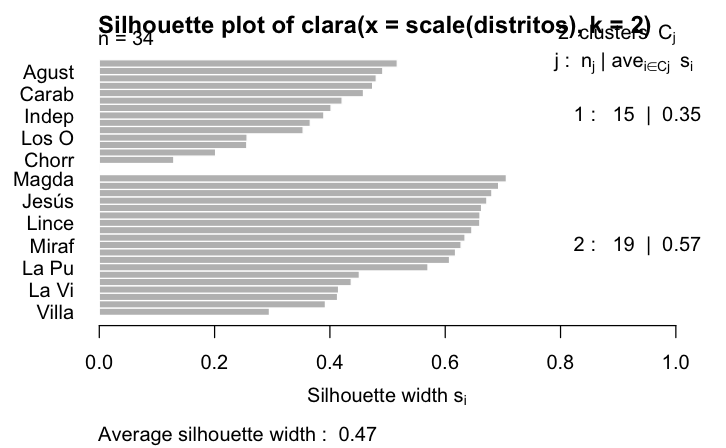

`r`r library() res=clara(scale(distritos),2, sampsize = 10)  
res

```
Call:    clara(x = scale(distritos), k = 2, sampsize = 10)
Medoids:
                                 ocu_vivi    pobpjov   sinelect    sinagua
Callao                          0.3647227  0.4196783  0.6147996  0.5420343
Breña                          -0.5317041 -0.9465086 -0.7313980 -0.1358897
                                  pea1619    pocprin     peam15
Callao                          0.6342951  0.4244607  0.8444664
Breña                          -0.7716537 -0.9139598 -0.3151707
Objective function:  1.718333
Clustering vector:   Named int [1:34] 1 2 2 1 1 1 1 1 2 2 2 2 1 1 2 2 2 2 ...
 - attr(*, \names\)= chr [1:34] \Ate                           \ \Barranco                      \ \Breña                         \ \Carabayllo                    \ \Comas                         \ \Chorrillos                    \ \Agustino                      \ ...
Cluster sizes:           15 19
Best sample:
 [1] Breña                          Comas
 [3] La Victoria                    Lince
 [5] San Juan de Miraflores         San Luis
 [7] San Martin de Porres           Villa el Salvador
 [9] Callao                         La Punta

Available components:
 [1] \sample\     \medoids\    \i.med\      \clustering\ \objective\
 [6] \clusinfo\   \diss\       \call\       \silinfo\    \data\
```

# Fuzzy C-Means (FCM): FANNY

Es un cluster difuso, es entre particional y difusa Se puede usar en los casos en que una observacion puede pertenecer a mas de un conglomerado

Caracteristicas: - Se asigna un coeficiente ($u_i$) para cada observacion y cluster - Los coeficientes no debe ser negativo - La suma de los coeficientes para una observacion debe ser 1

[output not shown]

## Obser. | 1 | 2 | . ……. | k

## 1 | u11 | u12 | ………| u1k

## 2 | u21 | u22 | ………| u2k

u11 + u12 + ……+ u1k = 1

La solucióm mas particional pasa cuando cualquiera de los coeficientes es 1, por ejemplo su u11 = 1, los demas coeficientes son 0.

La solución mas difusa es que cada coeficiente sea igual a 1/k , es decir las observaciones estan en todos los conglomerados.

Solamente se usa cuando quiero saber si un individuo esta en mas de un conglomerados.

Solo se puede evaluar una hipotesis si un individuo puede estar en mas de un conglomerados

Indice de Dunn, varia de [1/k ; 1]

si sale cercanod de 1/k, entonces valio la pena usar FANNY si sale cercano a 1, entonces no valio la pena usar FANNY

`r`r # Considerando 2 conglomerados res.fanny =fanny(scale(distritos),2) res.fanny

```
Fuzzy Clustering object of class 'fanny' :
m.ship.expon.        2
objective     26.52194
tolerance        1e-15
iterations          16
converged            1
maxit              500
n                   34
Membership coefficients (in %, rounded):
                               [,1] [,2]
Ate                              63   37
Barranco                         17   83
Breña                            19   81
Carabayllo                       74   26
Comas                            76   24
Chorrillos                       62   38
Agustino                         76   24
Independencia                    75   25
Jesús María                      19   81
La Victoria                      38   62
Lima                             35   65
Lince                            19   81
Los Olivos                       66   34
Lurigancho-Chosica               69   31
Magdalena del Mar                14   86
Pueblo Libre                     15   85
Miraflores                       23   77
Rímac                            39   61
San Borja                        20   80
San Isidro                       23   77
San Juan de Lurigancho           77   23
San Juan de Miraflores           82   18
San Luis                         38   62
San Martin de Porres             62   38
San Miguel                       23   77
Santa Anita                      77   23
Surco                            18   82
Surquillo                        21   79
Villa el Salvador                71   29
Villa María del Triunfo          45   55
```

[output cut: 32 more lines]

```
San Miguel                     Santa Anita
                             2                              1
Surco                          Surquillo
                             2                              2
Villa el Salvador              Villa María del Triunfo
                             1                              2
Callao                         Carmen de la Legua
                             1                              1
La Perla                       La Punta
                             2                              2

Available components:
 [1] \membership\  \coeff\       \memb.exp\    \clustering\  \k.crisp\
 [6] \objective\   \convergence\ \diss\        \call\        \silinfo\
[11] \data\
```

## La solucion mas particional :

Magdalena del Mar en el 2do Conglomerado : Tiene el mayor valor San Juan de Miraflores en el 1er Conglomerado : Tiene el mayor valor

En PAN los meloides eran Magdalena y San Juan de Miraflores, eran los meloidas porque eran lo mas representativos.

Una evaluacion estadisticas para saber que tan bien aplicamos FANNY es ver el indice de Dunn

`r`r head(res.fanny$membership, 3) # Coeficientes de pertenencia

```
                                    [,1]      [,2]
Ate                            0.6337041 0.3662959
Barranco                       0.1684934 0.8315066
Breña                          0.1892836 0.8107164
```

`r`r res.fanny$coeff # Coeficiente de Dunn

```
dunn_coeff normalized
 0.6187843  0.2375687
```

Se estandariza en Indice de Dunn y el valor es 0.23 que es cercano a 0, por lo tanto se concluye que FANNY fue adecuado.

`r`r head(res.fanny$clustering) # Grupos de pertenencia

```
Ate                            Barranco
                             1                              2
Breña                          Carabayllo
                             2                              1
Comas                          Chorrillos
                             1                              1
```

`r`r # Visualizar los conglomerados y la bondad de ajuste de los resulgados plot(res.fanny)

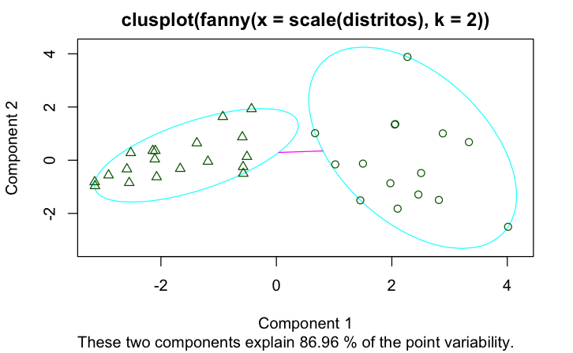

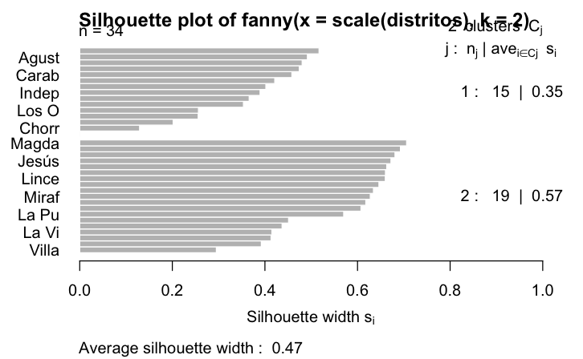

`r`r install.packages()

```r
fviz_silhouette(res.fanny, palette = "jco",
                ggtheme = theme_minimal())
```

[output not shown]

```r
# Seleccionar el n?mero de conglomerados
# Indice de Silueta
asw<-numeric()
for(h in 2:10){
  res<-fanny(scale(distritos),h,maxit=5000)
  asw[h-1]<-res$silinfo$avg.width
}
plot(2:10,asw,type="b",xlab="k",ylab="ASW")
```

[output not shown]

```r
par(mfrow=c(1,3))
for(h in 2:4){
  res=fanny(scale(distritos),h)
  plot(res,which.plots=2)
}
par(mfrow=c(1,1))
```

[output not shown]

```r
library(fpc)

# Indice de Calinski-Harabasz
ch<-numeric()
for(h in 2:10){
  res<-fanny(scale(distritos),h,maxit=5000)
  ch[h-1]<-calinhara(scale(distritos),res$clustering)
}
plot(2:10,ch,type="b",xlab="k",
ylab="Criterio de Calinski-Harabasz")
```

[output not shown]

# Métodos Jerarquicos

HCLUSTER

Algoritmo aglomeraticos , me dan 2 soluciones y me lo puedo expresar en un dendograma ( es el orden en que se van acumulando las observaciones en el conglomerado).

Si se tiene 2 conglomerados , y los voy agrupando de acuerdo a su singularidad, se aplica el metodo de enlace, para que un conglomerado sea representado se usa el enlace.

#——————————————————-# # Cluster Jer?rquico Aglomerativo # #——————————————————-#

```r
# Usando el enlace de Ward
res.hc=hclust(dist(scale(distritos)),method="ward.D") # Se muestra el metodo de enlace "word.D"
plot(res.hc)
```

[output not shown]

```r
# Usando el enlace de Ward
res.hc=hclust(dist(scale(distritos)),method="single") # Se muestra el metodo de enlace "single"
plot(res.hc)
```

[output not shown]

Es dificil hacer un analisis visual, para determinar cual conglomerado es el adecuado, se requiere definir un coeficiente que me indique que tan bien conformado estan dendograma en la grafica.

Para identificar el punto de corte, se usaba el indice de silueta

```r
# Cortando el dendrograma considerando cuatro conglomerados
(res.hc4=cutree(res.hc, k=4))  # cortar el conglomerado en 4 lugares sin importar la distancia , se le puede ingresar el parametro "h" que es la altura.
```

[output not shown]

```r
library(factoextra)
fviz_dend(res.hc, cex = 0.5, k = 4, palette = "jco")
```

[output not shown]

la funcion hclust() no me puede distinguir entre 2 dendogramas cual es el mejor con funcion de enlace distintas.

```r
#Clustering jerarquico aglomerativo usando Agnes
library(cluster)

# Usando el enlace simple
res.hc.s=hclust(dist(scale(distritos)),method="single")
plot(res.hc.s)
```

[output not shown]

```r
## Comparacion de enlaces
# Enlace de Ward
res.coph <- cophenetic(res.hc) # Distancia cofenetica
cor(dist(scale(distritos)), res.coph) # Correlacion entre la distancia cofen?tica y la original
```

[output not shown]

```r
# Enlace Simple
res.coph <- cophenetic(res.hc.s) # Distancia cofenetica
cor(dist(scale(distritos)), res.coph) # Correlacion entre la distancia cofen?tica y la original
```

[output not shown]

#——————————————————-# # AGNES # #——————————————————-#

```r
res.agnes.single = agnes(scale(distritos), method="single") # Se indica el tipo de enlace
res.agnes.single
plot(res.agnes.single)
```

[output not shown]

```r
res.agnes.ward=agnes(scale(distritos),method="ward")
res.agnes.ward
plot(res.agnes.ward)
```

[output not shown]

Pero deberia probarse al menos otros enlaces

```r
# Usando matriz de disimilaridad
diss.distritos=daisy(scale(distritos))
res.agnes.ward2 = agnes(diss.distritos,method="ward")

# Determinando el n?mero ?ptimo de conglomerados
# Indice de Silueta
par(mfrow=c(1,3))
for(h in 2:4){
  conglomerados=cutree(res.agnes.ward2,k=h)
  plot(silhouette(conglomerados,diss.distritos))
}
par(mfrow=c(1,1))
```

[output not shown]

```r
fviz_dend(res.agnes.ward2, cex = 0.5,
          k = 2,
          palette = "jco"
)
```

[output not shown]

#——————————————————-# # Algoritmo Divisivo (DIANA) # #——————————————————-# DIANA es un algoritmo de tipo divisivo,

```r
res.diana=diana(scale(distritos))
res.diana
plot(res.diana)
```

[output not shown]

```r
# Usando matriz de disimilaridad
diss.distritos=daisy(scale(distritos))
res=diana(diss.distritos)

# Determinando el n?mero ?ptimo de conglomerados
# Indice de Silueta
par(mfrow=c(1,3))
for(h in 2:4){
  conglomerados=cutree(res,h)
  plot(silhouette(conglomerados,diss.distritos))
}
```

[output not shown]

```r
fviz_dend(res.diana, cex = 0.5,
          k = 2,
          palette = "jco"
)
```

[output not shown]

# DBSCAN

```r
data("multishapes")
df <- multishapes[, 1:2]
df
```

| x | y |
| --- | --- |
| -8.037393e-01 | -0.853052609 |
| 8.528507e-01 | 0.367618437 |
| 9.271795e-01 | -0.274902438 |
| -7.526261e-01 | -0.511565170 |
| 7.068462e-01 | 0.810679197 |
| 1.034699e+00 | 0.394655023 |
| -4.758452e-01 | 0.989760805 |
| -4.603016e-01 | -0.858997793 |
| -6.803015e-01 | -0.661494813 |
| -1.031969e+00 | -0.021993545 |

[output cut: 990 more lines]

# Se aplica la tecnica de k medias para buscar 5 conglomerados

```r
set.seed(123)
km.res <- kmeans(df, 5, nstart = 25)
km.res
```

```
K-means clustering with 5 clusters of sizes 294, 210, 60, 261, 275

Cluster means:
           x           y
1  0.5908264 -0.08423474
2 -0.7158193 -2.48493748
3  0.9768879 -2.38945886
4 -0.2752881  0.52584306
5 -0.3617742 -0.49181836

Clustering vector:
   [1] 5 1 1 5 1 1 4 5 5 5 5 5 5 5 1 5 4 5 4 1 5 4 5 1 4 5 4 4 5 4 1 5 5 5 5
  [36] 4 4 4 5 5 1 5 4 5 5 4 4 5 4 4 4 4 4 5 4 1 1 5 1 4 1 1 4 4 5 1 5 1 1 1
  [71] 4 4 4 1 1 4 5 4 4 5 5 4 5 4 1 4 5 5 4 4 4 5 1 1 5 1 4 1 1 1 4 5 4 5 4
 [106] 1 5 4 1 5 5 5 5 1 5 1 5 4 1 4 4 5 1 1 1 5 5 4 5 1 1 4 5 4 4 5 5 4 1 4
```

[output cut: 36 more lines]

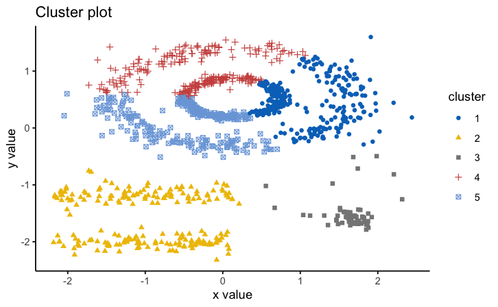

```r
fviz_cluster(km.res, df,  geom = "point",
             ellipse= FALSE, show.clust.cent = FALSE,
             palette = "jco", ggtheme = theme_classic())
```

La tecnica de las k medias trabaja con las distancias

```r
library("fpc")
library(dbscan)
set.seed(123)
# no es necesario estandarizarlo el dataset
db <- dbscan::dbscan(df,
                  eps = 0.15, # radio de la vecindad
                  MinPts = 5) # minimo numero de puntos con radio eps
```

```
converting argument MinPts (fpc) to minPts (dbscan)!
```

```r
# los valores eps y MinPts son valores que se tiene que ir calibrando
print(db)
```

```
DBSCAN clustering for 1100 objects.
Parameters: eps = 0.15, minPts = 5
The clustering contains 5 cluster(s) and 31 noise points.

  0   1   2   3   4   5
 31 410 405 104  99  51

Available fields: cluster, eps, minPts
```

Los que aparecen como 0 son observaciones que no van a ningun conglomerados

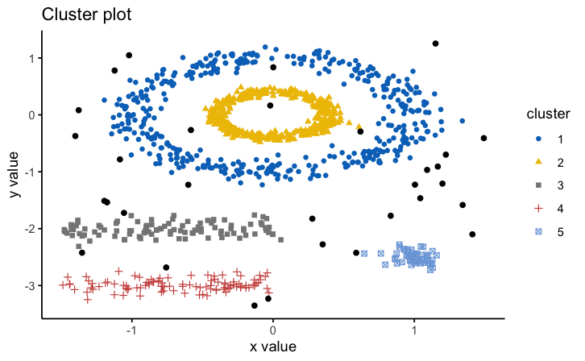

```r
# Graficar los resultados de DBSCAN
library("factoextra")
fviz_cluster(db, data = df, stand = FALSE,
             ellipse = FALSE, show.clust.cent = FALSE,
             geom = "point",palette = "jco", ggtheme = theme_classic())
```

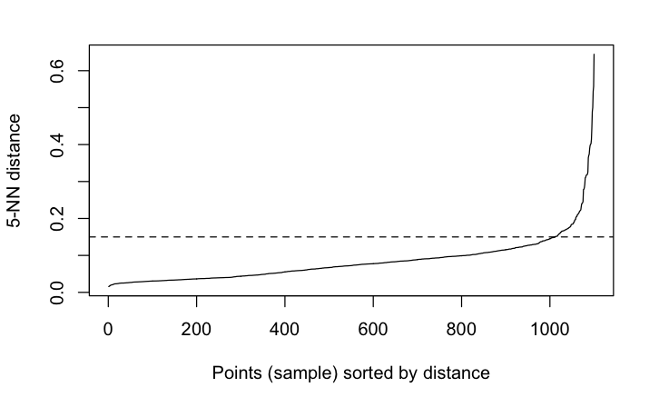

```r
# Valor optimo de eps
dbscan::kNNdistplot(df, k =  5)
abline(h = 0.15, lty = 2)
```

Visualmente se escoge donde la curva se desdobla

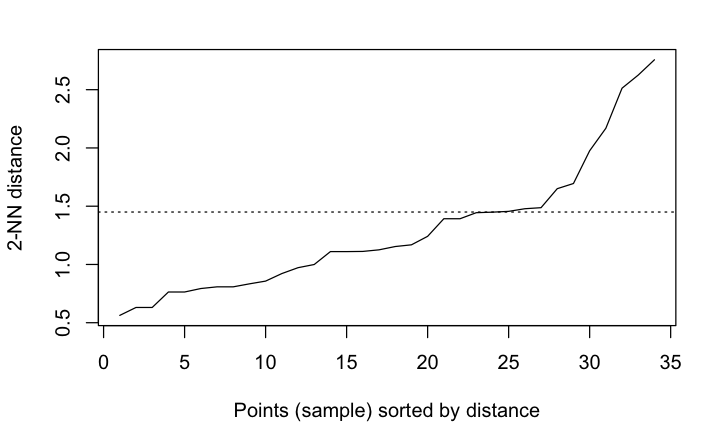

```r
# Ejemplo de Distritos
dbscan::kNNdistplot(scale(distritos), k =  2)
abline(h = 1.45, lty = 3)
```

No queda claro cual es el punto optimo, aprox 1.45

```r
set.seed(123)
res.db <- dbscan::dbscan(scale(distritos),
                  eps = 1.45, # radio de la vecindad
                  MinPts = 2) # m?nimo n?mero de puntos con radio eps
```

```
converting argument MinPts (fpc) to minPts (dbscan)!
```

```r
print(res.db)
```

```
DBSCAN clustering for 34 objects.
Parameters: eps = 1.45, minPts = 2
The clustering contains 3 cluster(s) and 6 noise points.

 0  1  2  3
 6 19  5  4

Available fields: cluster, eps, minPts
```

Aca aparecen los 3 conglomerados

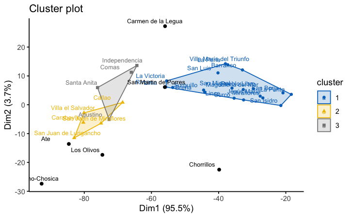

```r
fviz_cluster(res.db, data = distritos, stand = FALSE,
             ellipse = TRUE, show.clust.cent = FALSE,
             geom = c("point","text"),palette = "jco",
             ggtheme = theme_classic(),
             labelsize = 8,
             ellipse.type = "convex")
```

Esta es la solucion de DBSCAN